```python
# 622 Stochastic Modeling - GWP 1

############################################################################
##  __     __    __     ______   ______     ______     ______   ______    ##
## /\ \   /\ "-./  \   /\  == \ /\  __ \   /\  == \   /\__  _\ /\  ___\   ##
## \ \ \  \ \ \-./\ \  \ \  _-/ \ \ \/\ \  \ \  __<   \/_/\ \/ \ \___  \  ##
##  \ \_\  \ \_\ \ \_\  \ \_\    \ \_____\  \ \_\ \_\    \ \_\  \/\_____\ ##
##   \/_/   \/_/  \/_/   \/_/     \/_____/   \/_/ /_/     \/_/   \/_____/ ##
##                                                                        ##
############################################################################

import numpy as np
import pandas as pd
from scipy.integrate import quad
from scipy.optimize import brute, fmin
from matplotlib import pyplot as plt
from scipy.stats import norm
```

```python
# Given parameters
r = 1.50 / 100
trading_days = 250
S0 = 232.90

# Localizing the data

data = {
    "Days_to_Maturity": [15, 15, 15, 15, 15, 60, 60, 60, 60, 60, 120, 120, 120, 120, 120, 15, 15, 15, 15, 15, 60, 60, 60, 60, 60, 120, 120, 120, 120, 120],
    "Strike": [227.5, 230, 232.5, 235, 237.5, 227.5, 230, 232.5, 235, 237.5, 227.5, 230, 232.5, 235, 237.5, 227.5, 230, 232.5, 235, 237.5, 227.5, 230, 232.5, 235, 237.5, 227.5, 230, 232.5, 235, 237.5],
    "Price": [10.52, 10.05, 7.75, 6.01, 4.75, 16.78, 17.65, 16.86, 16.05, 15.10, 27.92, 24.12, 22.97, 21.75, 18.06, 4.32, 5.20, 6.45, 7.56, 8.78, 11.03, 12.15, 13.37, 14.75, 15.62, 14.53, 16.25, 17.22, 18.74, 19.73],
    "Type": ["C", "C", "C", "C", "C", "C", "C", "C", "C", "C", "C", "C", "C", "C", "C", "P", "P", "P", "P", "P", "P", "P", "P", "P", "P", "P", "P", "P", "P", "P"]
}

df = pd.DataFrame(data)
df["T"] = df["Days_to_Maturity"] / trading_days
df["r"] = r

options_60_DTM = df[(df["Days_to_Maturity"] == 60) & (df["Type"] == "C")]
options_60_DTM
```

|  | Days_to_Maturity | Strike | Price | Type | T | r |
| --- | --- | --- | --- | --- | --- | --- |
| 5 | 60 | 227.5 | 16.78 | C | 0.24 | 0.015 |
| 6 | 60 | 230.0 | 17.65 | C | 0.24 | 0.015 |
| 7 | 60 | 232.5 | 16.86 | C | 0.24 | 0.015 |
| 8 | 60 | 235.0 | 16.05 | C | 0.24 | 0.015 |
| 9 | 60 | 237.5 | 15.10 | C | 0.24 | 0.015 |

# Step 1.a -- Student A

```python
# Given parameters
r = 1.50 / 100
trading_days = 250
S0 = 232.90

# Load data
options = df
options["T"] = options["Days_to_Maturity"] / trading_days
options["r"] = r


# Filter 15 days maturity calls
options = options[(options['Days_to_Maturity'] == 15) & (options['Type'] == 'C')]
options
```

|  | Days_to_Maturity | Strike | Price | Type | T | r |
| --- | --- | --- | --- | --- | --- | --- |
| 0 | 15 | 227.5 | 10.52 | C | 0.06 | 0.015 |
| 1 | 15 | 230.0 | 10.05 | C | 0.06 | 0.015 |
| 2 | 15 | 232.5 | 7.75 | C | 0.06 | 0.015 |
| 3 | 15 | 235.0 | 6.01 | C | 0.06 | 0.015 |
| 4 | 15 | 237.5 | 4.75 | C | 0.06 | 0.015 |

```python
def H93_char_func(u, T, r, kappa_v, theta_v, sigma_v, rho, v0):
    """Valuation of European call option in H93 model via Lewis (2001)
    Fourier-based approach: characteristic function.
    Parameter definitions see function BCC_call_value."""
    c1 = kappa_v * theta_v
    c2 = -np.sqrt(
        (rho * sigma_v * u * 1j - kappa_v) ** 2 - sigma_v**2 * (-u * 1j - u**2)
    )
    c3 = (kappa_v - rho * sigma_v * u * 1j + c2) / (
        kappa_v - rho * sigma_v * u * 1j - c2
    )
    H1 = r * u * 1j * T + (c1 / sigma_v**2) * (
        (kappa_v - rho * sigma_v * u * 1j + c2) * T
        - 2 * np.log((1 - c3 * np.exp(c2 * T)) / (1 - c3))
    )
    H2 = (
        (kappa_v - rho * sigma_v * u * 1j + c2)
        / sigma_v**2
        * ((1 - np.exp(c2 * T)) / (1 - c3 * np.exp(c2 * T)))
    )
    char_func_value = np.exp(H1 + H2 * v0)
    return char_func_value

def H93_int_func(u, S0, K, T, r, kappa_v, theta_v, sigma_v, rho, v0):
    """
    Fourier-based approach for Lewis (2001): Integration function.
    """
    char_func_value = H93_char_func(
        u - 1j * 0.5, T, r, kappa_v, theta_v, sigma_v, rho, v0
    )
    int_func_value = (
        1 / (u**2 + 0.25) * (np.exp(1j * u * np.log(S0 / K)) * char_func_value).real
    )
    return int_func_value

def H93_call_value(S0, K, T, r, kappa_v, theta_v, sigma_v, rho, v0):
    """Valuation of European call option in H93 model via Lewis (2001)

    Parameter definition:
    ==========
    S0: float
        initial stock/index level
    K: float
        strike price
    T: float
        time-to-maturity (for t=0)
    r: float
        constant risk-free short rate
    kappa_v: float
        mean-reversion factor
    theta_v: float
        long-run mean of variance
    sigma_v: float
        volatility of variance
    rho: float
        correlation between variance and stock/index level
    v0: float
        initial level of variance
    Returns
    =======
    call_value: float
        present value of European call option
    """
    int_value = quad(
        lambda u: H93_int_func(u, S0, K, T, r, kappa_v, theta_v, sigma_v, rho, v0),
        0,
        np.inf,
        limit=250,
    )[0]
    call_value = max(0, S0 - np.exp(-r * T) * np.sqrt(S0 * K) / np.pi * int_value)
    return call_value

def put_value_from_call(call_value, S0, K, T, r):
    """
    Calculates the European put option price using Put-Call parity.

    Parameters:
    ===========
    call_value : float
        Price of the European call option.
    S0 : float
        Current stock/index level.
    K : float
        Strike price.
    T : float
        Time to maturity (in years).
    r : float
        Constant risk-free short rate.

    Returns:
    ========
    put_value : float
        Price of the European put option.
    """
    put_value = call_value + K * np.exp(-r * T) - S0
    return put_value
```

```python
# H93 Calibration

i = 0
min_MSE = 500

def H93_error_function(p0):
    """Error function for parameter calibration via
    Lewis (2001) Fourier approach for Heston (1993).
    Parameters
    ==========
    kappa_v: float
        mean-reversion factor
    theta_v: float
        long-run mean of variance
    sigma_v: float
        volatility of variance
    rho: float
        correlation between variance and stock/index level
    v0: float
        initial, instantaneous variance
    Returns
    =======
    MSE: float
        mean squared error
    """
    global i, min_MSE
    kappa_v, theta_v, sigma_v, rho, v0 = p0
    if kappa_v < 0.0 or theta_v < 0.005 or sigma_v < 0.0 or rho < -1.0 or rho > 1.0:
        return 500.0
    if 2 * kappa_v * theta_v < sigma_v**2:
        return 500.0
    se = []
    for row, option in options.iterrows():
        model_value = H93_call_FFT(
            S0,
            option["Strike"],
            option["T"],
            option["r"],
            kappa_v,
            theta_v,
            sigma_v,
            rho,
            v0,
        )
        se.append((model_value - option["Price"]) ** 2)
    MSE = sum(se) / len(se)
    min_MSE = min(min_MSE, MSE)
    if i % 25 == 0:
        print("%4d |" % i, np.array(p0), "| %7.3f | %7.3f" % (MSE, min_MSE))
    i += 1
    return MSE

def H93_calibration_full():
    """Calibrates Heston (1993) stochastic volatility model to market quotes."""
    # First run with brute force
    # (scan sensible regions, for faster convergence)
    p0 = brute(
        H93_error_function,
        (
            (2.5, 10.6, 1.0),  # kappa_v
            (0.01, 0.041, 0.01),  # theta_v
            (0.05, 0.251, 0.01),  # sigma_v
            (-0.75, 0.01, 0.1),  # rho
            (0.01, 0.031, 0.01),  # v0
        ),
        finish=None,
    )

    # Second run with local, convex minimization
    # (we dig deeper where promising results)
    opt = fmin(
        H93_error_function, p0, xtol=0.000001, ftol=0.000001, maxiter=1500, maxfun=900
    )
    return opt

def H93_calculate_model_values(p0):
    kappa_v, theta_v, sigma_v, rho, v0 = p0
    values = []
    for row, option in options.iterrows():
        model_value = H93_call_FFT(
            S0,
            option["Strike"],
            option["T"],
            option["r"],
            kappa_v,
            theta_v,
            sigma_v,
            rho,
            v0
        )

        values.append(model_value)

    return np.array(values)
```

```python
# Get optimum parameter values
kappa_v, theta_v, sigma_v, rho, v0 = H93_calibration_full()
student_A_full_params = kappa_v, theta_v, sigma_v, rho, v0

print("Optimum parameters =", student_A_full_params)
```

```
   0 | [ 2.5   0.01  0.05 -0.75  0.01] |  23.560 |  23.560
  25 | [ 2.5   0.01  0.06 -0.75  0.02] |  16.683 |  11.974
  50 | [ 2.5   0.01  0.07 -0.75  0.03] |  11.969 |  11.969
  75 | [ 2.5   0.01  0.08 -0.65  0.01] |  23.559 |  11.967
 100 | [ 2.5   0.01  0.09 -0.65  0.02] |  16.683 |  11.966
 125 | [ 2.5   0.01  0.1  -0.65  0.03] |  11.970 |  11.964
 150 | [ 2.5   0.01  0.11 -0.55  0.01] |  23.568 |  11.964
 175 | [ 2.5   0.01  0.12 -0.55  0.02] |  16.692 |  11.963
 200 | [ 2.5   0.01  0.13 -0.55  0.03] |  11.978 |  11.963
 225 | [ 2.5   0.01  0.14 -0.45  0.01] |  23.587 |  11.963
 250 | [ 2.5   0.01  0.15 -0.45  0.02] |  16.709 |  11.963
 275 | [ 2.5   0.01  0.16 -0.45  0.03] |  11.993 |  11.963
 300 | [ 2.5   0.01  0.17 -0.35  0.01] |  23.616 |  11.963
 325 | [ 2.5   0.01  0.18 -0.35  0.02] |  16.734 |  11.963
 350 | [ 2.5   0.01  0.19 -0.35  0.03] |  12.014 |  11.963
```

[output cut: 768 more lines]

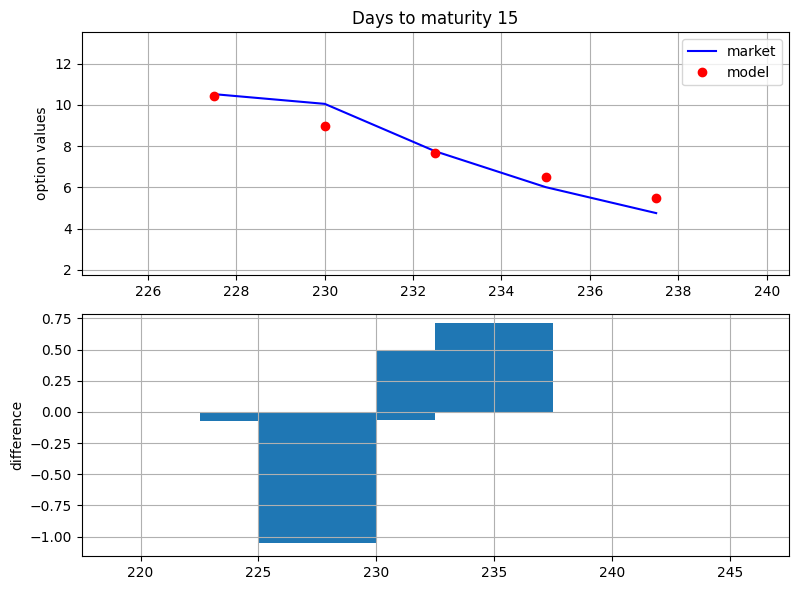

```python
def plot_full_calibration_results(p0):
    options["Model"] = H93_calculate_model_values(p0)
    plt.figure(figsize=(8, 6))
    plt.subplot(211)
    plt.grid()
    plt.title("Days to maturity %s" % str(options["Days_to_Maturity"].iloc[0])[:10])
    plt.ylabel("option values")
    plt.plot(options.Strike, options.Price, "b", label="market")
    plt.plot(options.Strike, options.Model, "ro", label="model")
    plt.legend(loc=0)
    plt.axis(
        [
            min(options.Strike) - 3,
            max(options.Strike) + 3,
            min(options.Price) - 3,
            max(options.Price) + 3,
        ]
    )
    plt.subplot(212)
    plt.grid()
    wi = 5.0
    diffs = options.Model.values - options.Price.values
    plt.bar(options.Strike.values - wi / 2, diffs, width=wi)
    plt.ylabel("difference")
    plt.axis(
        [
            min(options.Strike) - 10,
            max(options.Strike) + 10,
            min(diffs) * 1.1,
            max(diffs) * 1.1,
        ]
    )
    plt.tight_layout()

plot_full_calibration_results(student_A_full_params)
```

We used the Days to Maturity value of 15 days and the MSE as the error function of the model. As observed in the graphs, the modeled points for the calibration results follow a trend that is similar to the market option values reported, which suggests that the fit of the calibration is reasonably accurate enough to model option prices for a short time period.

However, the gradient of the modeled prices is not similar to that of reported market prices, which will cause larger deviations of prices modeled versus in the market for values that are far OTM or ITM, which may result in inaccurate results and may make the model ineffective.

# Step 1.b -- Student B, Using Carr-Madan (1999) to calibrate Heston (1993)

```python
# Given parameters
r = 1.50 / 100
trading_days = 250
S0 = 232.90

# Load data
filepath = r"C:\Users\Atakan\atakan_python\WQU_DP\WQU_SM\GWP1\MScFE 622_Stochastic Modeling_GWP1_Option data.xlsx"
options = pd.read_excel(filepath, header=0)
options["T"] = options["Days to maturity"] / trading_days
options["r"] = r


# Filter 15 days maturity calls
options = options[(options['Days to maturity'] == 15) & (options['Type'] == 'C')]
options
```

|  | Days to maturity | Strike | Price | Type | T | r |
| --- | --- | --- | --- | --- | --- | --- |
| 0 | 15 | 227.5 | 10.52 | C | 0.06 | 0.015 |
| 1 | 15 | 230.0 | 10.05 | C | 0.06 | 0.015 |
| 2 | 15 | 232.5 | 7.75 | C | 0.06 | 0.015 |
| 3 | 15 | 235.0 | 6.01 | C | 0.06 | 0.015 |
| 4 | 15 | 237.5 | 4.75 | C | 0.06 | 0.015 |

```python
import numpy as np

def H93_char_func(u, T, r, kappa_v, theta_v, sigma_v, rho, v0):
    """Characteristic function for the Heston model."""
    # Parameters for the characteristic function
    alpha = -u * u * 0.5 - u * 0.5j
    beta = kappa_v - rho * sigma_v * u * 1j
    gamma = sigma_v ** 2 / 2
    d = np.sqrt(beta ** 2 - 4 * alpha * gamma)
    rp = (beta + d) / (2 * gamma)
    rm = (beta - d) / (2 * gamma)
    g = rm / rp
    # Avoid division by zero and log of zero
    exp_dT = np.exp(-d * T)
    G = (1 - g * exp_dT) / (1 - g)
    # Characteristic function
    C = r * u * 1j * T + (kappa_v * theta_v) / (sigma_v ** 2) * (
        (beta - d) * T - 2 * np.log(G)
    )
    D = (beta - d) / (sigma_v ** 2) * ((1 - exp_dT) / (1 - g * exp_dT))
    char_func_value = np.exp(C + D * v0)
    return char_func_value

def H93_call_FFT(S0, K, T, r, kappa_v, theta_v, sigma_v, rho, v0):
    """Call option price in Heston (1993) under FFT (Carr and Madan approach)"""
    k = np.log(K / S0)
    g = 1  # Factor to increase accuracy
    N = g * 4096
    eps = (g * 150) ** -1
    eta = 2 * np.pi / (N * eps)
    b = 0.5 * N * eps - k
    u = np.arange(1, N + 1, 1)
    vo = eta * (u - 1)

    # Modifications to ensure integrability
    if S0 >= 0.95 * K:  # In-the-money case
        alpha = 1.5
        v = vo - (alpha + 1) * 1j
        modcharFunc = np.exp(-r * T) * (
            H93_char_func(v, T, r, kappa_v, theta_v, sigma_v, rho, v0)
            / (alpha ** 2 + alpha - vo ** 2 + 1j * (2 * alpha + 1) * vo)
        )
    else:  # Out-of-the-money case
        alpha = 1.1
        v = vo - 1j * (alpha + 1)
        modcharFunc1 = np.exp(-r * T) * (
            1 / (1 + 1j * (vo - 1j * alpha))
            - np.exp(r * T) / (1j * (vo - 1j * alpha))
            - H93_char_func(
                v, T, r, kappa_v, theta_v, sigma_v, rho, v0
            )
            / ((vo - 1j * alpha) ** 2 - 1j * (vo - 1j * alpha))
        )
        v = vo + 1j * (alpha - 1)
        modcharFunc2 = np.exp(-r * T) * (
            1 / (1 + 1j * (vo + 1j * alpha))
            - np.exp(r * T) / (1j * (vo + 1j * alpha))
            - H93_char_func(
                v, T, r, kappa_v, theta_v, sigma_v, rho, v0
            )
            / ((vo + 1j * alpha) ** 2 - 1j * (vo + 1j * alpha))
        )

    # Numerical FFT Routine
    delt = np.zeros(N)
    delt[0] = 1
    j = np.arange(1, N + 1, 1)
    SimpsonW = (3 + (-1) ** j - delt) / 3
    if S0 >= 0.95 * K:
        FFTFunc = np.exp(1j * b * vo) * modcharFunc * eta * SimpsonW
        payoff = (np.fft.fft(FFTFunc)).real
        CallValueM = np.exp(-alpha * k) / np.pi * payoff
    else:
        FFTFunc = (
            np.exp(1j * b * vo) * (modcharFunc1 - modcharFunc2) * 0.5 * eta * SimpsonW
        )
        payoff = (np.fft.fft(FFTFunc)).real
        CallValueM = payoff / (np.sinh(alpha * k) * np.pi)

    pos = int((k + b) / eps)
    CallValue = CallValueM[pos] * S0

    return CallValue

def put_price_from_call(call_price, S0, K, T, r):
    """
    Calculates the European put option price using Put-Call parity.

    Parameters:
    ===========
    call_price : float
        Price of the European call option.
    S0 : float
        Current stock/index level.
    K : float
        Strike price.
    T : float
        Time to maturity (in years).
    r : float
        Constant risk-free short rate.

    Returns:
    ========
    put_price : float
        Price of the European put option.
    """
    put_price = call_price + K * np.exp(-r * T) - S0
    return put_price
```

```python
# H93 Calibration

i = 0
min_MSE = 500

def H93_error_function(p0):
    """Error function for parameter calibration via
    Lewis (2001) Fourier approach for Heston (1993).
    Parameters
    ==========
    kappa_v: float
        mean-reversion factor
    theta_v: float
        long-run mean of variance
    sigma_v: float
        volatility of variance
    rho: float
        correlation between variance and stock/index level
    v0: float
        initial, instantaneous variance
    Returns
    =======
    MSE: float
        mean squared error
    """
    global i, min_MSE
    kappa_v, theta_v, sigma_v, rho, v0 = p0
    if kappa_v < 0.0 or theta_v < 0.005 or sigma_v < 0.0 or rho < -1.0 or rho > 1.0:
        return 500.0
    if 2 * kappa_v * theta_v < sigma_v**2:
        return 500.0
    se = []
    for row, option in options.iterrows():
        model_value = H93_call_FFT(
            S0,
            option["Strike"],
            option["T"],
            option["r"],
            kappa_v,
            theta_v,
            sigma_v,
            rho,
            v0,
        )
        se.append((model_value - option["Price"]) ** 2)
    MSE = sum(se) / len(se)
    min_MSE = min(min_MSE, MSE)
    if i % 25 == 0:
        print("%4d |" % i, np.array(p0), "| %7.3f | %7.3f" % (MSE, min_MSE))
    i += 1
    return MSE

def H93_calibration_full():
    """Calibrates Heston (1993) stochastic volatility model to market quotes."""
    # First run with brute force
    # (scan sensible regions, for faster convergence)
    p0 = brute(
        H93_error_function,
        (
            (2.5, 10.6, 1.0),  # kappa_v
            (0.01, 0.041, 0.01),  # theta_v
            (0.05, 0.251, 0.01),  # sigma_v
            (-0.75, 0.01, 0.1),  # rho
            (0.01, 0.031, 0.01),  # v0
        ),
        finish=None,
    )

    # Second run with local, convex minimization
    # (we dig deeper where promising results)
    opt = fmin(
        H93_error_function, p0, xtol=0.000001, ftol=0.000001, maxiter=1500, maxfun=900
    )
    return opt

def H93_calculate_model_values(p0):
    kappa_v, theta_v, sigma_v, rho, v0 = p0
    values = []
    for row, option in options.iterrows():
        model_value = H93_call_FFT(
            S0,
            option["Strike"],
            option["T"],
            option["r"],
            kappa_v,
            theta_v,
            sigma_v,
            rho,
            v0
        )

        values.append(model_value)

    return np.array(values)
```

```python
# Get optimum parameter values
kappa_v, theta_v, sigma_v, rho, v0 = H93_calibration_full()
student_B_full_params = kappa_v, theta_v, sigma_v, rho, v0

print("Optimum parameters =", student_B_full_params)
```

```
   0 | [ 2.5   0.01  0.05 -0.75  0.01] |  23.560 |  23.560
  25 | [ 2.5   0.01  0.06 -0.75  0.02] |  16.683 |  11.974
  50 | [ 2.5   0.01  0.07 -0.75  0.03] |  11.969 |  11.969
  75 | [ 2.5   0.01  0.08 -0.65  0.01] |  23.559 |  11.967
 100 | [ 2.5   0.01  0.09 -0.65  0.02] |  16.683 |  11.966
 125 | [ 2.5   0.01  0.1  -0.65  0.03] |  11.970 |  11.964
 150 | [ 2.5   0.01  0.11 -0.55  0.01] |  23.568 |  11.964
 175 | [ 2.5   0.01  0.12 -0.55  0.02] |  16.692 |  11.963
 200 | [ 2.5   0.01  0.13 -0.55  0.03] |  11.978 |  11.963
 225 | [ 2.5   0.01  0.14 -0.45  0.01] |  23.587 |  11.963
 250 | [ 2.5   0.01  0.15 -0.45  0.02] |  16.709 |  11.963
 275 | [ 2.5   0.01  0.16 -0.45  0.03] |  11.993 |  11.963
 300 | [ 2.5   0.01  0.17 -0.35  0.01] |  23.616 |  11.963
 325 | [ 2.5   0.01  0.18 -0.35  0.02] |  16.734 |  11.963
 350 | [ 2.5   0.01  0.19 -0.35  0.03] |  12.014 |  11.963
```

[output cut: 768 more lines]

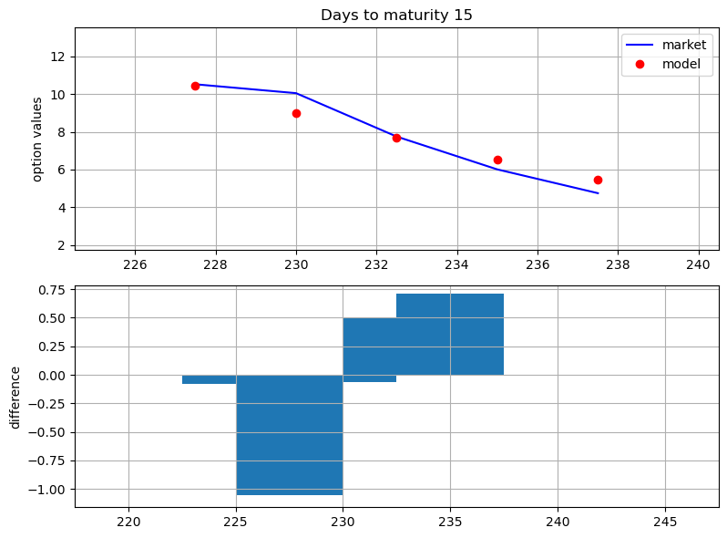

```python
def plot_full_calibration_results(p0):
    options["Model"] = H93_calculate_model_values(p0)
    plt.figure(figsize=(8, 6))
    plt.subplot(211)
    plt.grid()
    plt.title("Days to maturity %s" % str(options["Days to maturity"].iloc[0])[:10])
    plt.ylabel("option values")
    plt.plot(options.Strike, options.Price, "b", label="market")
    plt.plot(options.Strike, options.Model, "ro", label="model")
    plt.legend(loc=0)
    plt.axis(
        [
            min(options.Strike) - 3,
            max(options.Strike) + 3,
            min(options.Price) - 3,
            max(options.Price) + 3,
        ]
    )
    plt.subplot(212)
    plt.grid()
    wi = 5.0
    diffs = options.Model.values - options.Price.values
    plt.bar(options.Strike.values - wi / 2, diffs, width=wi)
    plt.ylabel("difference")
    plt.axis(
        [
            min(options.Strike) - 10,
            max(options.Strike) + 10,
            min(diffs) * 1.1,
            max(diffs) * 1.1,
        ]
    )
    plt.tight_layout()

plot_full_calibration_results(student_B_full_params)
```

# Step 1.c -- Student C

```python
# Parameters chosen from Step 1.b

step1c_full_params = (12.420752920991287, 0.17015492867696463, 4.667599168668949e-07, 0.6796937736319705, 0.07780470979890447)
s1c_kappa_v, s1c_theta_v, s1c_sigma_v, s1c_rho, s1c_v0 = step1c_full_params
```

```python
class Heston_MC_Asian(object):
    def __init__(self, S, K, T, t, r, sigma, kappa_v, sigma_v, theta_v, rho, M, Ite):
        self.__S = S
        self.__K = K
        self.__T = T
        self.__t = t
        self.__r = r
        self.__sigma = sigma
        self.__kappa_v = kappa_v
        self.__sigma_v = sigma_v
        self.__theta_v = theta_v
        self.__rho = rho
        self.__M = M
        self.__Ite = Ite

    def get_price(self):
        return self.__price

    def get_final_payoffs(self):
        return self.__final_payoffs

    def get_average_payoff(self):
        return self.__average_payoff

    def payoff(self, stock_prices):
        raise NotImplementedError()

    def price(self):
        self.__dt = self.__T / self.__M
        self.__sdt = np.sqrt(self.__dt)
        self.__stock_prices = np.zeros((self.__M + 1, self.__Ite))
        self.__stock_prices[0] = self.__S

        rand = np.random.standard_normal((2, self.__M + 1, self.__Ite))

        covariance_matrix = np.zeros((2, 2), dtype=float)
        covariance_matrix[0] = [1.0, self.__rho]
        covariance_matrix[1] = [self.__rho, 1.0]
        cho_matrix = np.linalg.cholesky(covariance_matrix)

        V = np.zeros((self.__M + 1, self.__Ite), dtype=float)
        V[0] = self.__sigma

        for i in range(1, self.__M + 1):
            ran = np.dot(cho_matrix, rand[:, i])
            V[i] = np.maximum(
                0,
                V[i - 1]
                + self.__kappa_v * (self.__theta_v - V[i - 1]) * self.__dt
                + np.sqrt(V[i - 1]) * self.__sigma_v * ran[1] * self.__sdt,
            )

        for j in range(1, self.__M + 1):
            ran = np.dot(cho_matrix, rand[:, j])
            self.__stock_prices[j] = self.__stock_prices[j - 1] * np.exp(
                (self.__r - 0.5 * V[j]) * self.__dt + np.sqrt(V[j]) * ran[0] * self.__sdt
            )

        self.__final_payoffs = self.payoff(np.mean(self.__stock_prices, axis = 0))
        self.__average_payoff = np.mean(self.__final_payoffs)
        self.__price = np.exp(-self.__r * (self.__T)) * (self.__average_payoff)

class Heston_MC_Call_Asian(Heston_MC_Asian):
    def __init__(self, **kwargs):
        required_keys = ['S', 'K', 'T', 't', 'r', 'sigma', 'kappa_v', 'sigma_v', 'theta_v', 'rho', 'M', 'Ite']

        # Ensure all required keys are provided
        for key in required_keys:
            if key not in kwargs:
                raise TypeError(f"Missing required keyword argument(s): '{list(set(required_keys) - set(kwargs))}'")

        self.__K = kwargs['K']
        super().__init__(**kwargs)

    def payoff(self, stock_prices):
        return np.maximum(stock_prices - self.__K, 0)
```

```python
np.random.seed(42)

HestonCall = Heston_MC_Call_Asian(S=232.9, K=0.95*232.9, T=20/250, t=0, r=0.015, sigma=s1c_v0,
                                             kappa_v=s1c_kappa_v, sigma_v=s1c_sigma_v, theta_v=s1c_theta_v, rho=s1c_rho,
                                             M=20, Ite=100000)
HestonCall.price()
print(f'Heston Call Price: {HestonCall.get_price()}')
print(f'Heston Call Price with 4% fee: {HestonCall.get_price() * 1.04}')

############ OUTPUT
# Heston Call Price: 12.617920087565
# Heston Call Price with 4% fee: 13.1226368910676
```

```
Heston Call Price: 12.617920087565
Heston Call Price with 4% fee: 13.1226368910676
```

To price this Asian Call option, we used the Heston Model. The Heston Model, unlike other models, allows for volatility (how fast the price of the stock can change) is NOT constant. This adds an extra layer of realism, and helps to create a fairer option value for you.

After we finished tuneing, we did tens of thousands of simulations to make sure we map out the different ways the price of the stock can move to create a forecast for the final stock value. We took the average of the forecast to hone-in on the final stock price, which we used to calculate the final value of the option.

Our goal is to provide you with most informed price, so we added a **4% fee** on top of the option price as a part of our service. This fee covers the costs of managing and pricing the option, using the Heston Model. This fee is similar to an insurance premium, or to one you would pay a financial planner.